# ggplot2 : 4. Summarized Data Distributions

```r
# install.packages(c('ggplot2’, 'gcookbook’), dependencies = TRUE)
library(ggplot2)
library(gcookbook)
```

## Making a Basic Histogram

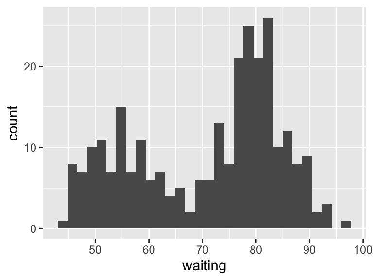

```r
ggplot(faithful, aes(x = waiting)) + geom_histogram()
```

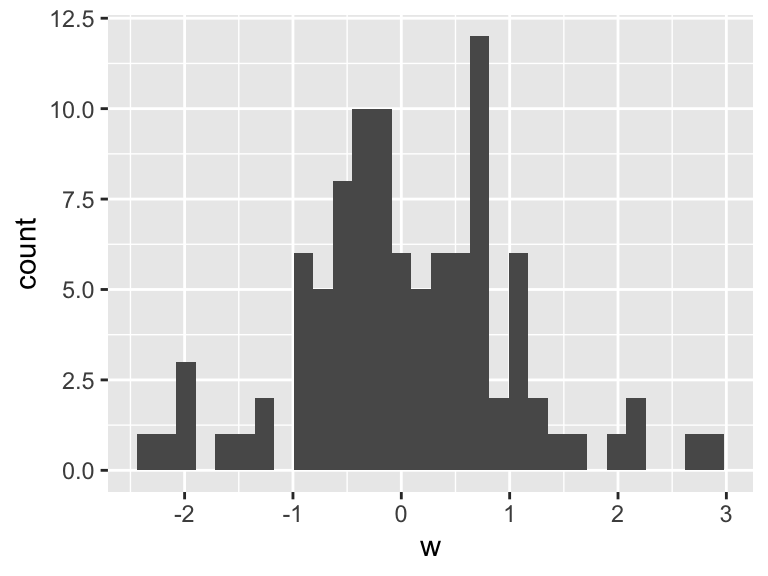

```r
w <- rnorm(100)
ggplot(NULL, aes(x = w)) + geom_histogram()
```

- `geom_histogram()` : 연속형 변수에 대한 histogram을 그림.
- 연속형 자료가 data frame이 아닌 벡터로 저장된 경우 data 이름 위치에 NULL 지정.

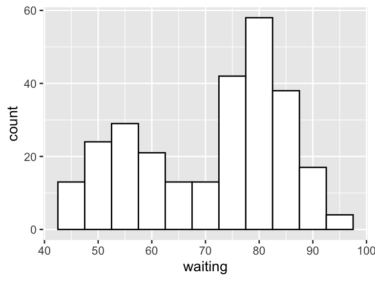

```r
ggplot(faithful, aes(x = waiting)) +
  geom_histogram(binwidth = 5, fill = 'white', color = 'black')
```

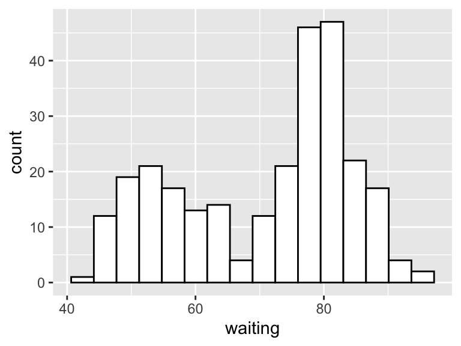

```r
binsize <- diff(range(faithful$waiting)) / 15
ggplot(faithful, aes(x = waiting)) +
  geom_histogram(binwidth = binsize, fill = 'white', color = 'black')
```

- `binwidth`는 히스토그램의 구간폭을 지정함.
- `diff(range(faithful$waiting)) / 15` : 변수 waiting의 범위 (최대값과 최소값의 차이)의 15분의 1의 길이를 지정.

## Making Multiple Histograms from Grouped Data

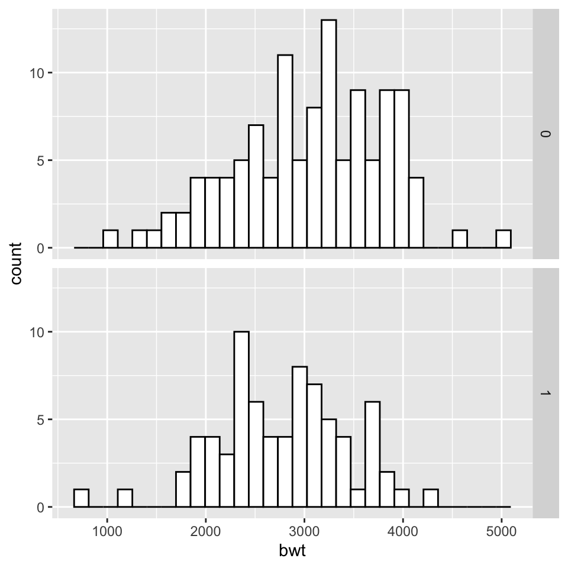

```r
library(MASS)
ggplot(birthwt, aes(x = bwt)) + geom_histogram(fill = 'white', color = 'black') +
  facet_grid(smoke ~ .)
```

- `facet_grid(smoke ~ .)` : 변수 smoke의 레벨별로 ggplot + geom 에 설정된 그래픽을 출력함.
- facet에 대한 자세한 설명은 **9. FACETS**를 참조.

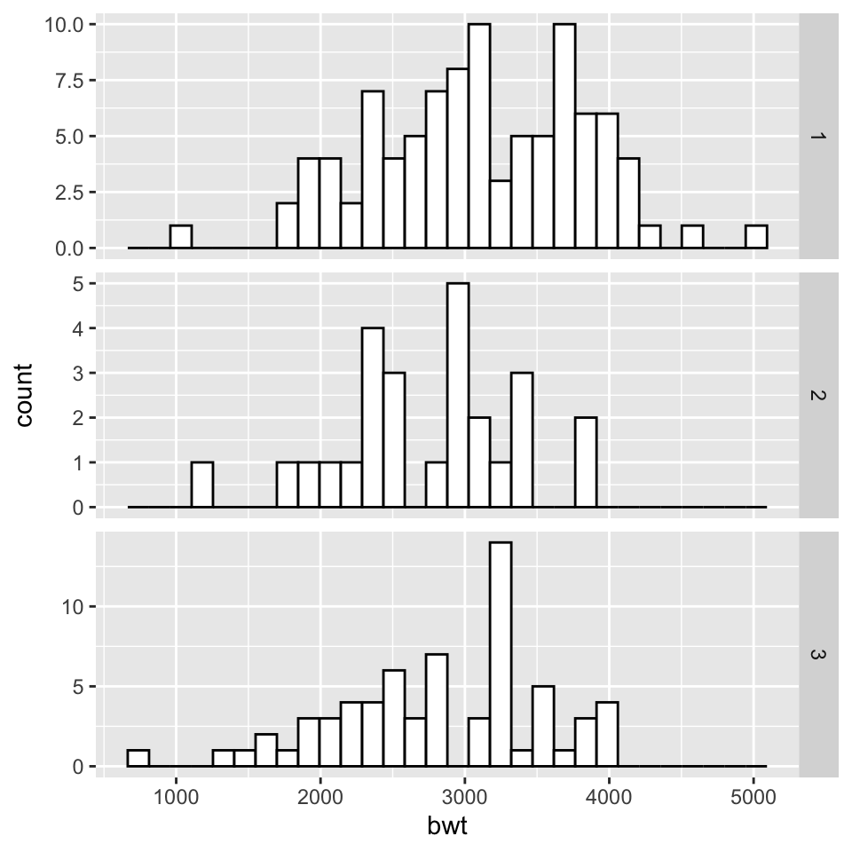

```r
# scale = 'free'
ggplot(birthwt, aes(x = bwt)) + geom_histogram(fill = 'white', color = 'black') +
  facet_grid(race ~ ., scale = 'free')
```

- `scale = ‘free’` : facet에 그려지는 각 패널의 축을 동일하게 일치시키는 것을 해제함.

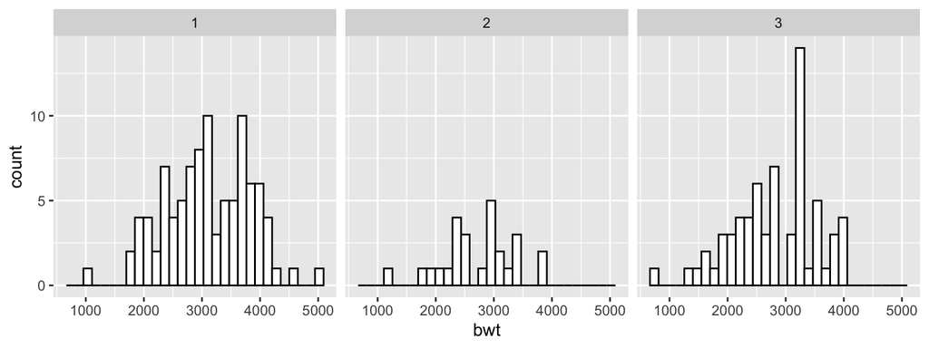

```r
# change the facet
ggplot(birthwt, aes(x = bwt)) + geom_histogram(fill = 'white', color = 'black') +
  facet_grid(. ~ race)
```

- `facet_grid(var ~ .)` 는 var의 레벨별로 그래프를 세로로 그리며 `facet_grid(. ~ var)` 는 var의 레벨별로 그래프를 가로로 그림.

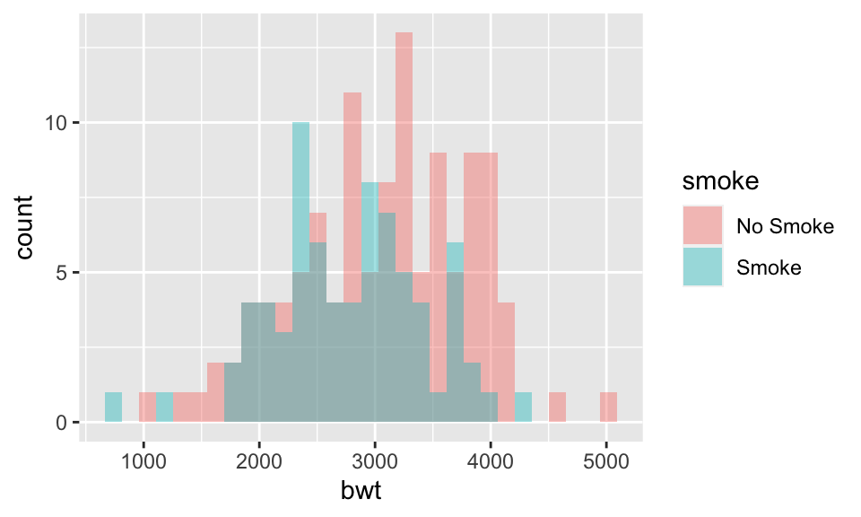

```r
birthwt1 <- birthwt
birthwt1$smoke <- factor(birthwt1$smoke, levels = c(0, 1), labels = c('No Smoke', 'Smoke'))
ggplot(birthwt1, aes(x = bwt, fill = smoke)) +
  geom_histogram(position = 'identity', alpha = 0.4)
```

- aes함수에 `fill = smoke`를 지정하고 `geom_histogram(position = ‘identity’)`하면 변수 smoke의 두 레벨에 대응하는 히스토그램이 겹쳐서 그려짐.

## Making a Density Curve

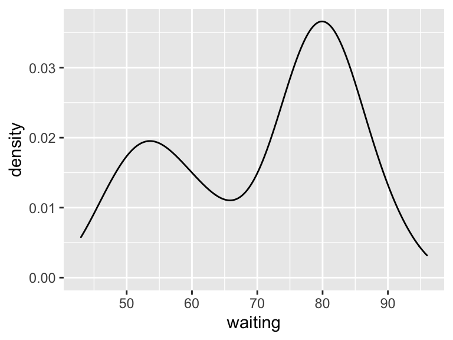

```r
ggplot(faithful, aes(x = waiting)) + geom_density()
```

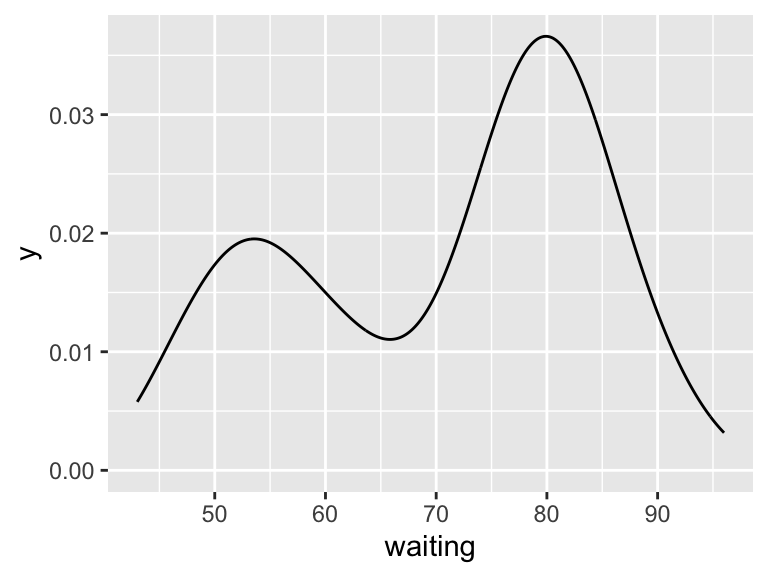

```r
ggplot(faithful, aes(x = waiting)) + geom_line(stat = 'density') + expand_limits(y = 0)
```

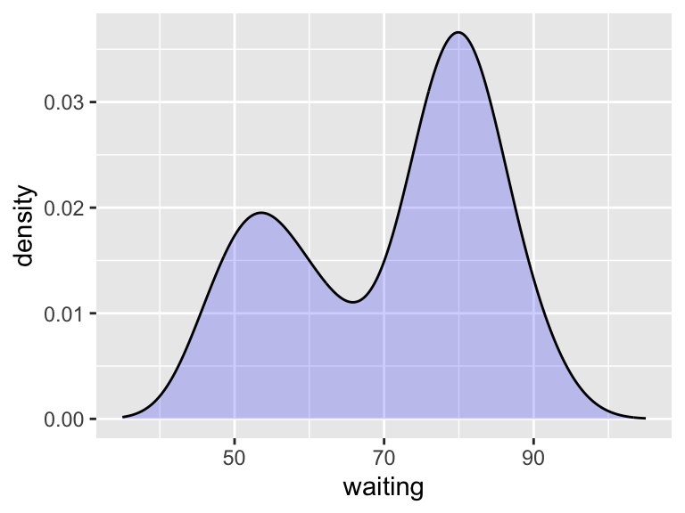

```r
# adding colors
ggplot(faithful, aes(x = waiting)) +
  geom_density(fill = 'blue', color = NA, alpha = 0.2) +
  geom_line(stat = 'density') +
  xlim(35, 105)
```

- `geom_density()` 및 `geom_line()`을 조합하여 density plot의 아랫부분의 선을 없애는 예시.
- `geom_density()` 함수 내부에 `fill = ‘blue’`는 density curve 아래영역 색상을 blue로 정하고, 곡선의 색은 `color = NA`, 즉 색상을 지정하지 않음. 결과로써 푸른색 둘레는 색상을 지정하지 않음.
- `geom_line(stat = ‘density’)` 함수는 density 곡선을 검정색으로 표현함.
- `xlim(35, 105)` : x축의 범위를 35에서 105 사이에 그려지도록 함.

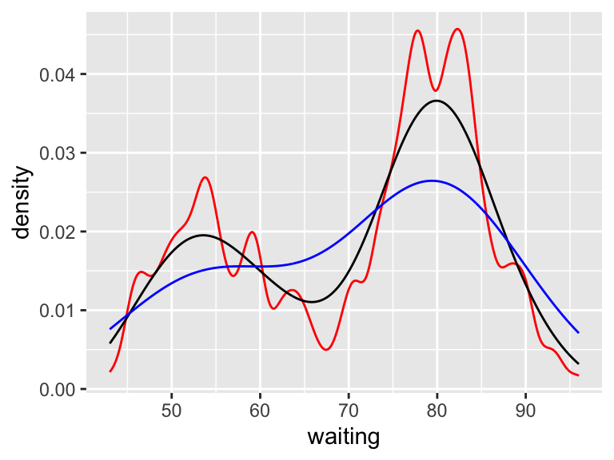

```r
ggplot(faithful, aes(x = waiting)) +
  geom_line(stat = 'density', adjust = 0.25, color = 'red') +
  geom_line(stat = 'density') +
  geom_line(stat = 'density', adjust = 2, color = 'blue')
```

- `adjust` : density curve를 추정할때 고려한 binwith를 조정함. 작은값은 local feature를 많이 반영되어 density 곡선이 less smooth하게 추정되며 큰 값은 more smooth하게 추정함. default는 1.

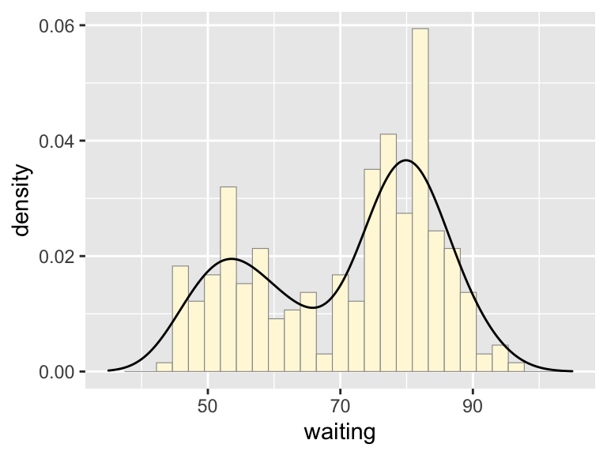

```r
ggplot(faithful, aes(x = waiting, y = ..density..)) +
  geom_histogram(fill = 'cornsilk', color = 'grey60', size = 0.2) +
  geom_density() + xlim(35, 105)
```

- `geom_histogram()` 과 `geom_density()` 를 동시에 적용함으로써 히스토그램과 density 곡선을 동시에 그림.
- `..density..` 는 `geom_density()` 가 수행되면서 내부적으로 생성되는 density function 값을 저장한 내부변수임.

## Making Multiple Density from Grouped Data

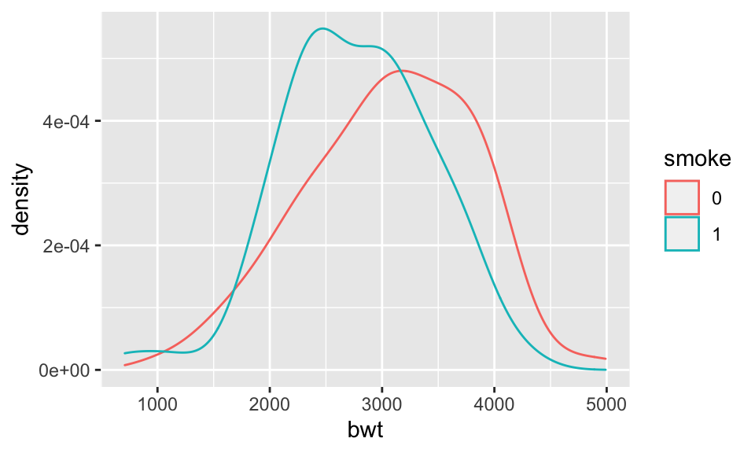

```r
birthwt1 <- birthwt
birthwt1$smoke <- factor(birthwt1$smoke)
ggplot(birthwt1, aes(x = bwt, color = smoke)) + geom_density()
```

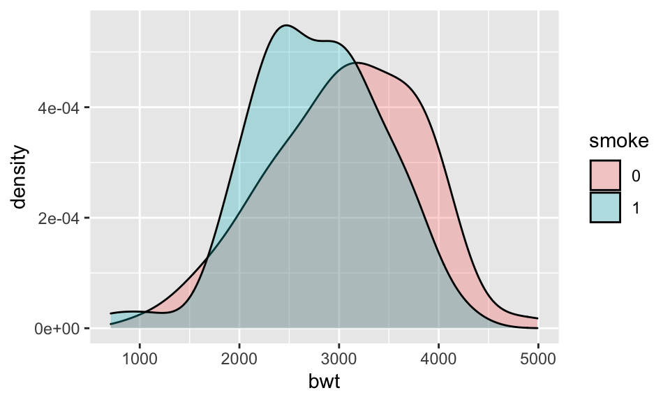

```r
ggplot(birthwt1, aes(x = bwt, fill = smoke)) + geom_density(alpha = 0.3)
```

- 옵션 `color`, `fill`을 이용하여 그룹별 density 곡선을 동시에 그릴 수 있음.

## Making a Basic Box Plot

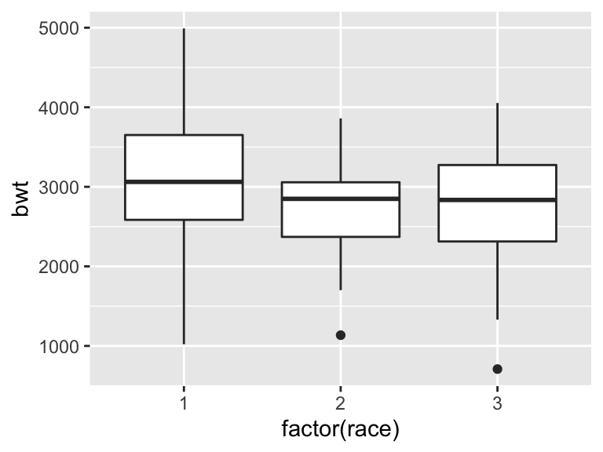

```r
ggplot(birthwt, aes(x = factor(race), y = bwt)) + geom_boxplot()
```

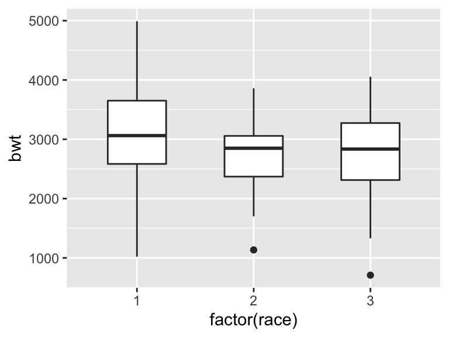

```r
ggplot(birthwt, aes(x = factor(race), y = bwt)) + geom_boxplot(width = 0.5)
```

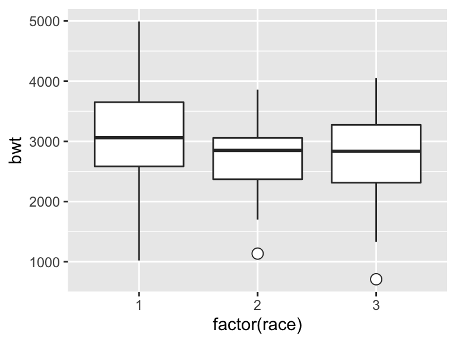

```r
ggplot(birthwt, aes(x = factor(race), y = bwt)) +
  geom_boxplot(outlier.size = 3, outlier.shape = 21)
```

- outlier 모양을 바꿈. `outlier.size` 는 outlier의 크기를 지정하고 `outlier.shape` 은 모양을 지정함 (`outlier.colour`는 색상 지정).

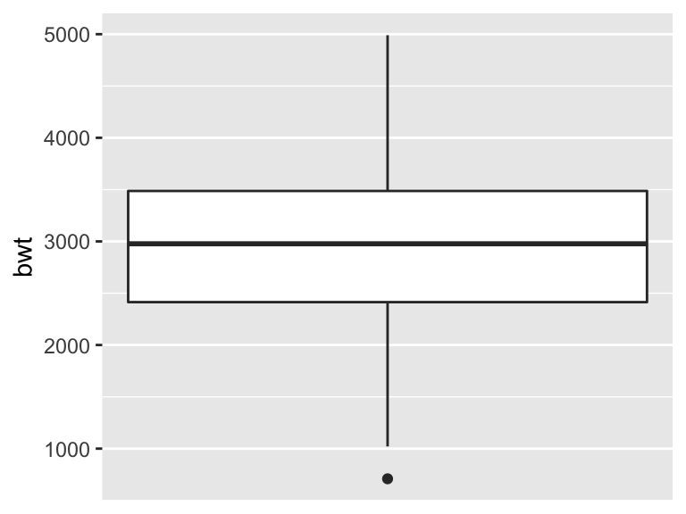

```r
ggplot(birthwt, aes(x = 1, y = bwt)) + geom_boxplot() +
  scale_x_continuous(breaks = NULL) +
  theme(axis.title.x = element_blank())
```

- 그룹이 아닌 단일한 자료에 대한 상자그림을 그리는 예시.
- aes 함수에서 x변수를 지정할 수 없으므로 대신 1을 지정. 이러한 경우 그림에서 x축에 스케일이 의미가 없으므로 `scale_x_continuous(breaks = NULL)`을 지정함. 또한 x의 변수값 표현이 의미가 없으므로 `axis.title.x = element_blank()`를 지정함.

## Adding Means to a Box Plot

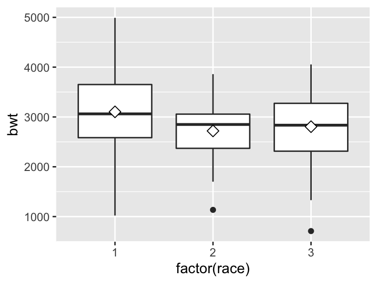

```r
ggplot(birthwt, aes(x = factor(race), y = bwt)) + geom_boxplot() +
  stat_summary(fun = 'mean', geom = 'point', shape = 23, size = 3, fill = 'white')
```

## Making a Basic Dot Plot

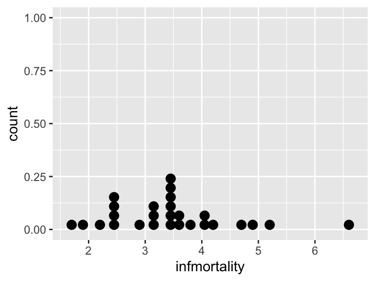

```r
countries2009 <- subset(countries, Year == 2009 & healthexp > 2000)
p <- ggplot(countries2009, aes(x = infmortality))
p + geom_dotplot()
```

- `geom_dotplot()` : 점그림을 그림.

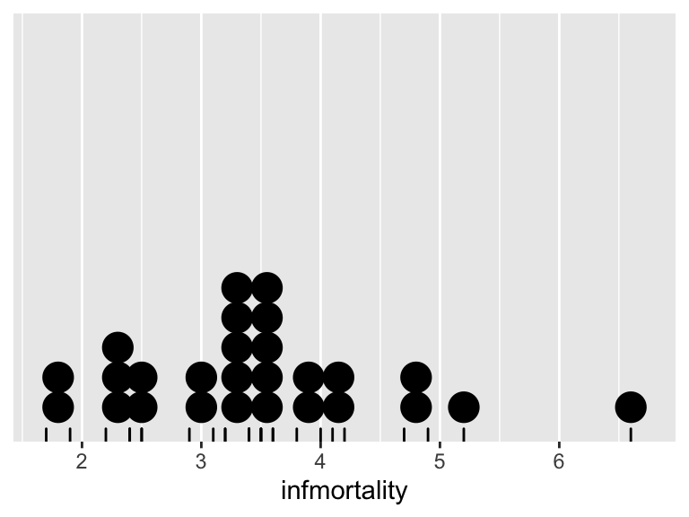

```r
p + geom_dotplot(binwidth = 0.25) + geom_rug() +
  scale_y_continuous(breaks = NULL) + # remove tick marks
  theme(axis.title.y = element_blank()) # remove axis label
```

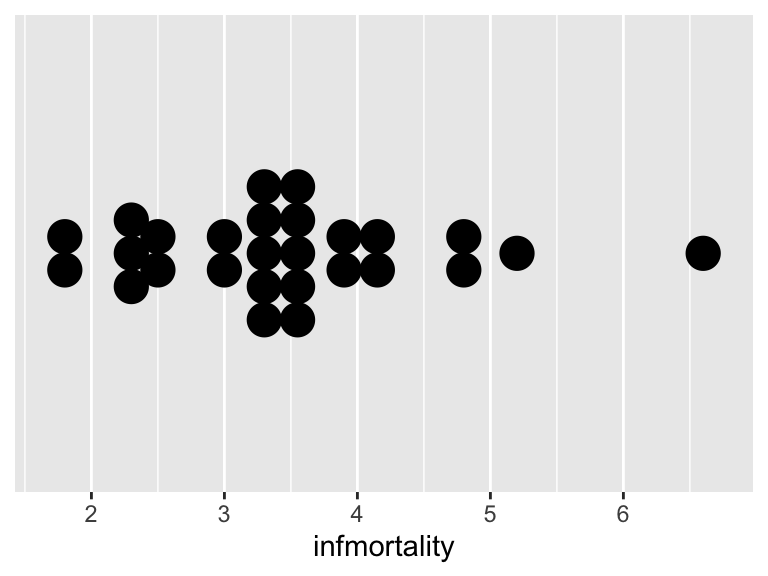

```r
p + geom_dotplot(binwidth = 0.25, stackdir = 'center') +
  scale_y_continuous(breaks = NULL) + # remove tick marks
  theme(axis.title.y = element_blank()) # remove axis label
```

- `scale_y_continuous(breaks = NULL)` 및 `theme(axis.title.y = element_blank())` : y축의 count 정보와 관련된 tick 과 label을 출력하지 않음.
- `stackdir = ‘center’` : dot plot을 가운데로 정렬.

## Making a Density Plot of Two-Dimensional Data

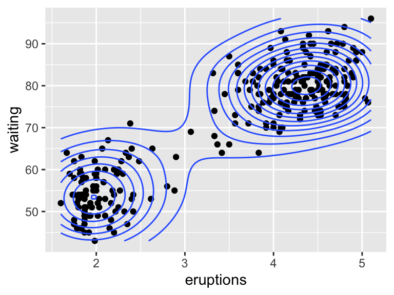

```r
p <- ggplot(faithful, aes(x = eruptions, y = waiting))
p + geom_point() + stat_density2d()
```

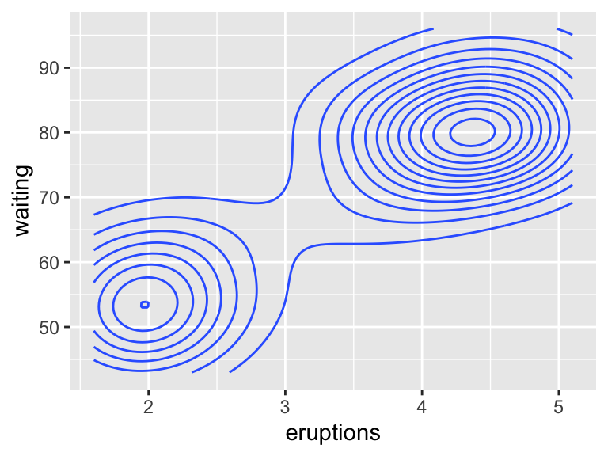

```r
p + stat_density2d()
```

- `stat_density2d()` : 2차원 자료에 대한 density 곡선을 추정하여 그림.

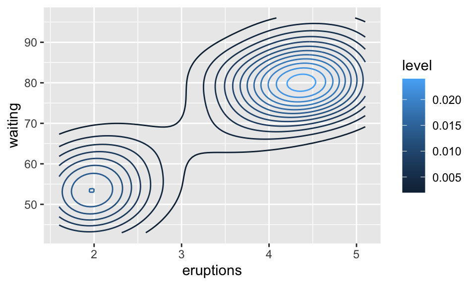

```r
p + stat_density2d(aes(color = ..level..))
```

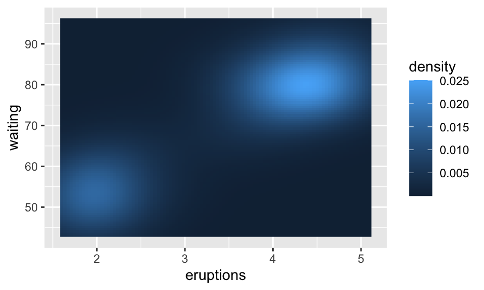

```r
p + stat_density2d(aes(fill = ..density..), geom = 'raster', contour = FALSE)
```

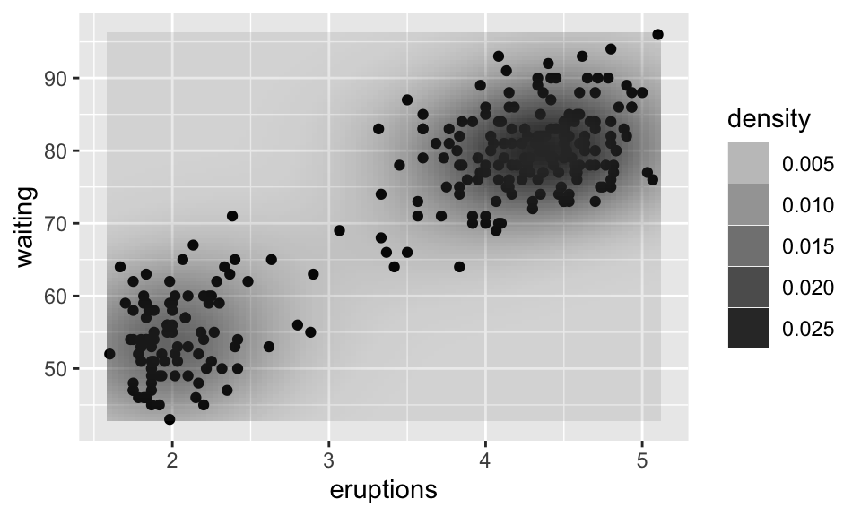

```r
p + geom_point() +
  stat_density2d(aes(alpha = ..density..), geom = 'tile', contour = FALSE)
```

- `color = ..level..` : 등고선의 색상을 등고선 높이 값에 따라 달리함. 여기서 `..level..`은 `stat_density2d()`에서 제공하는 내부변수로 등고선의 높이 정보를 가짐.
- `fill = ..density..` : 색상을 추정된 density function 값의 크기에 따라 설정함.
- `alpha = ..density..` : 색상의 투명도를 추정된 density function 값의 크기에 따라 설정함.